# INFO831 - Informatique décisionnelle

## Partie I : Régressions

### 1. Régression linéaire simple

Le but d'une **régression linéaire** est de comprendre comment une variable X (**explicative**) influence une variable Y (**expliquée**).

La relation entre ces deux variables est supposée être descriptible par une fonction affine (la droite de régression) :

$$Y = \omega X + b$$

Ici :

- $X = \{x_1, x_2, ..., x_n\}$ est un vecteur de valeurs de la variable explicative
- $Y = \{y_1, y_2, ..., y_n\}$ est un vecteur de valeurs de la variable expliquée
- $\omega$ est le coefficient de proportionalité (pente) de la droite de régression
- $b$ est l'ordonnée à l'origine (interception) de la droite de régression

Pour déterminer la droite à utiliser, il existe plusieurs méthodes :

- Line fitting :  
  C'est la plus nulle, on trace simplement des droites dans un nuage de points et on garde celle qui semble le mieux coller à la distribution des points.
- Minimisation du coût :  
  On cherche ici à minimiser une fonction de coût définie à l'avance. En général, la fonction utilisée est la moyenne de la somme des carrés des résidus (MSE) :
  - $MSE = \large{\frac{1}{n} \sum_{i=1}^{n} (Y_{predit}(i) - Y_{reel}(i))^2}$
  - $\omega = \large{\frac{\sum_{i=1}^{n} (X(i) - \bar{X})(Y(i) - \bar{Y})}{\sum_{i=1}^{n} (X(i) - \bar{X})^2}} = \frac{N(\sum_n{X_nY_n})-(\sum_n{X_n})(\sum_n{Y_n})}{N(\sum_n{X_n^2})-(\sum_n{X_n})^2} = \frac{cov(X, Y)}{var(X)}$
  - $b = \bar{Y} - \omega \bar{X} = \large{\frac{(\sum_n{Y_n}) - \omega(\sum_n{X_n})}{N}}$  
    (ici $\bar{X}$ représente la moyenne de $X$)
- Méthode de la médiane-médiane :  
  *(imcomplet)*

Avec les paramètres du modèle de régression, il est possible de prédire de nouvelles valeurs. Pour ce faire, il suffit de remplacer les valeurs de $X$ dans l'équation de la droite de régression. Il existe deux types de prédictions :

- Interpolation : prédire des valeurs de $Y$ pour des valeurs de $X$ comprises dans l'intervalle de valeurs de $X$ utilisées pour l'apprentissage
- Extrapolation : prédire des valeurs de $Y$ pour des valeurs de $X$ en dehors de l'intervalle de valeurs de $X$ utilisées pour l'apprentissage

### 2. Evaluation de qualité de modèle

Pour évaluer la qualité d'un modèle de régression, il existe plusieurs métriques qui permettre de mesure la relation entre la variable X et Y.

#### 2.1. Erreur quadratique moyenne (MSE)

L'erreur quadratique moyenne est une mesure caractérisant la précision d'un modèle.

Comme vu précedemment, elle se calcule avec :

$$MSE = \frac{1}{n} \sum_{i=1}^{n} (\hat{Y}_{predit}(i) - Y_{reel}(i))^2$$

#### 2.2. p-value

La p-value est une mesure statistique qui désigne la probabilité d'obtenir un résultat au moins aussi extrême que celui observé, en supposant que l'hypothèse nulle est vraie. En gros, c'est la probabilité que la relation entre les variables X et Y soit due au hasard.  
Une valeur faible (inférieure à 0.05) indique que la relation entre les variables est significative.  
Une valeur plus importante indique au contraire que nous n'avons pas assez de preuves pour rejeter l'hypothèse nulle (càd pour prouver que ce n'est pas du hasard).

#### 2.3. Corrélation R² et R² ajusté

Le coefficient de détermination R² est une mesure statistique qui indique la proportion de la variance de la variable expliquée qui est expliquée par la variable explicative.

Soit **$SST$** la somme totale des carrés des différences entre chaque valeur réelle et la moyenne de Y :

$$SST = \sum_{i=1}^{n} (Y(i) - \bar{Y})^2$$

Soit **$SSR$** la somme des carrés des résidus (différence entre chaque valeur réelle et la valeur prédite par le modèle) :

$$SSR = \sum_{i=1}^{n} (Y(i) - \hat{Y}_{predit}(i))^2$$

Le coefficient de détermination R² est alors défini comme :

$$R^2 = 1 - \frac{SSR}{SST}, R^2 \in [0,1]$$

La valeur de $R^2$ peut être interprétée comme suit :

- $R^2 = 1$ : le modèle explique parfaitement la variance de Y
- $R^2 = 0$ : le modèle n'explique pas du tout la variance de Y

Le coefficient de détermination ajusté $R^2_{adj}$ (ou $\bar{R}^2$) est une version corrigée de $R^2$ qui prend en compte le nombre de variables explicatives dans le modèle. Il est défini comme :

$$R^2_{adj} = 1 - \frac{SSR/df_r}{SST/df_t} = 1 - \frac{(1 - R^2)(n - 1)}{n - p - 1}, R^2_{adj} \in [-\infty, 1]$$

avec :

- $SSR$ et $SST$ les mêmes que précédemment
- $df_r = n - p - 1$ le degré de liberté du modèle (nombre de paramètres estimés)
- $df_t = n - 1$ le degré de liberté total (nombre d'observations - 1)
- $n$ la taille de l'échantillon (= nombre d'observations)
- $p$ le nombre de variables explicatives

On peut aussi le calculer comme :

$$R^2_{adj} = 1 - ((1 - R^2)\frac{n-1}{n-p-1})$$

$R^2_{adj}$ peut prendre une valeur négative et sera toujours inférieur ou égal à $R^2$. Plus $R^2_{adj}$ est proche de 1, plus le modèle est bon. Il a l'avantage de pénaliser les modèles avec un trop grand nombre de variables explicatives, ce qui permet d'éviter le surapprentissage.

*Exemple :*

Soit un nombre d'heures de travail par élève sur un projet $X$ = [2, 3, 4, 5, 6] et la note obtenue $Y$ = [65, 72, 75, 82, 88].

On a :

- $N = 5$
- $\sum{X} = 20$
- $\sum{Y} = 382$
- $\sum{X^2} = 90$
- $\sum{XY} = 1584$
- $\bar{Y} = 76.4$

Donc :

- $\omega = \frac{(5*1584) - (20*382)}{(5*90) - 20^2} = 5.6$
- $b = \frac{382 - (5.6 * 20)}{5} = 54$

La droite de régression est donc : $Y = 5.6X + 54$

On peut alors calculer $R^2$ :

- $SST = \sum_{i=1}^{5} (Y(i) - \bar{Y})^2 = (65-76.4)^2 + (72-76.4)^2 + (75-76.4)^2 + (82-76.4)^2 + (88-76.4)^2 = 317.2$
- $SSR = \sum_{i=1}^{5} (Y(i) - \hat{Y}_{predit}(i))^2 = (65-65.2)^2 + (72-70.8)^2 + (75-76.4)^2 + (82-82)^2 + (88-87.6)^2 = 3.6$
- $R^2 = 1 - \frac{3.6}{317.2} = 0.9887$

On peut alors en déduire que 98.87% de la variance de la note obtenue par les élèves est expliquée par le nombre d'heures de travail sur le projet.  
Pour prédire la note d'un élève ayant travaillé 3.5 heures, on a : $Y = 5.6*3.5 + 54 = 73.6$.  
Cependant, ce modèle a des limites : il ne prend pas en compte une note maximale, et la note minimale qu'il peut accorder (0h de travail) est de 54.

### 3. Régression linéaire multiple

#### 3.1 Définition

La régression linéaire multiple est une extension de la régression linéaire simple. Elle permet de modéliser la relation entre une variable expliquée $Y$ et plusieurs variables explicatives $X_1, X_2, ..., X_n$.

La relation entre ces variables est décrite par la fonction suivante :

$$Y = \omega_1 X_1 + \omega_2 X_2 + ... + \omega_n X_n + b$$

Ici, chaque $\omega_i$ représente le coefficient de la variable explicative $X_i$. Le but est de trouver les valeurs de $\omega_i$ qui minimisent la somme des carrés des résidus (MSE).

Le calcul des coefficients $\omega_i$ se fait de la même manière que pour la régression linéaire simple :

$$\omega_i = \frac{N(\sum_n{X_iY})-(\sum_n{X_i})(\sum_n{Y})}{N(\sum_n{X_i^2})-(\sum_n{X_i})^2} = \frac{cov(X_i, Y)}{var(X_i)}$$

$b = \bar{Y} - \sum_{i=1}^{m} \omega_i \bar{X_i}$ (avec $m$ le nombre de variables explicatives).

#### 3.2 Calcul matriciel

Il est possible de résoudre le problème de la régression linéaire multiple en utilisant des calculs matriciels.

Soit $X$ la matrice des variables explicatives, $Y$ le vecteur des valeurs de la variable expliquée, $\omega$ le vecteur des coefficients et $b$ l'ordonnée à l'origine. On a alors :

$$Y = X\omega + b$$

Pour trouver les valeurs de $\omega$ et $b$ qui minimisent la somme des carrés des résidus, on peut utiliser la formule suivante :

$$\omega = (X^TX)^{-1}X^TY$$

avec $(X^TX)$ la matrice de variance-covariance des variables explicatives

### 4. Régression logistique

#### 4.1 Définition

L'objectif de la régression logistique est de prédire la probabilité qu'un événement se produise en fonction de variables explicatives. Contrairement à la régression linéaire, la régression logistique est utilisée pour prédire des variables binaire.

On cherche à obtenir un résultat entre 0 et 1, qui représente la probabilité que l'événement se produise. Pour cela, on utilise généralement la fonction sigmoïde :

$$\sigma(u) = \frac{1}{1 + e^{-u}} = \hat{y}$$
avec $u = \omega_1 X_1 + \omega_2 X_2 + ... + \omega_n X_n + b$ ici.

#### 4.2 Fonction de coût

Les fonctions de coût les plus utilisées pour la régression logistique sont l'entropie croisée (cross-entropy) et l'erreur quadratique moyenne (MSE).

L'entropie croisée est définie comme :

$$J(\omega) = -\frac{1}{n} \sum_{i=1}^{n} [y_i log(\hat{y}_i) + (1 - y_i) log(1 - \hat{y}_i)]$$

et l'erreur quadratique moyenne comme :

$$MSE = \frac{1}{n} \sum_{i=1}^{n} (\hat{y}_i - y_i)^2$$

avec $y_i$ la valeur réelle de la variable binaire, $\hat{y}_i$ la valeur prédite par le modèle.

#### 4.3. Estimation de paramètres

Pour estimer les paramètres du modèle de régression logistique, il est possible d'utiliser deux méthodes :

##### 4.3.1. Calcul analytique

Comme pour la régression linéaire, on cherche à minimiser une fonction de coût $\large\varepsilon$. Un ensemble de paramètres $v^*$ correspond à un argument d'un minimum local de $\large\varepsilon$ si et seulement si :

- Le gradient de $\large\varepsilon$  
  en $v$ est nul en $v^*$ : $\nabla_{v} \large\varepsilon(v^*) = 0$
- La matrice hessienne de $\large\varepsilon$ en $v^*$ est définie positive : $\nabla_{v}^2 \large\varepsilon(v^*) > 0$

##### 4.3.2. Descente de gradient

L'algorithme de descente de gradient est une méthode itérative qui permet de trouver les valeurs des paramètres qui minimisent une fonction de coût.

En théorie, on cherche à générer une série $(v^k)_k$ de vecteurs de paramètres de sorte que la série $(\large\varepsilon(v^k))_k$ soit décroissante, avec :

**$$v^{k+1} = v^k - \lambda^kd^k$$**

avec :

- $d^k$ le vecteur de direction de descente $d^k = -\nabla_{v} \large\varepsilon(v^k)$,
- $\lambda^k$ l'hyperparamètre de descente (learning rate) qui détermine la taille du pas de la descente.

##### 4.3.3. Algorithme de descente de gradient

1. Initialisation : $v^k = v^0 \in \mathbb{R}^n$, $\lambda^k > 0$, $k = 0$,
2. Calcul de la direction de descente : $d^k = -\nabla_{v} \large\varepsilon(v^k)$,
3. Test de convergence : si $\|d^k\| \cong 0$ alors arrêt, sinon continuer,
4. Sélection/calcul de la taille du pas $\lambda^k$,
5. Mise à jour des paramètres : $v^k \leftarrow v^k + \lambda^kd^k$ et $k \leftarrow k + 1$ puis retour à l'étape 2.

*Exemple :*

Soit la fonction $f(x) = y = (x-2)^2$

On cherche à minimiser cette fonction en utilisant les deux méthodes.

**Calcul analytique :**

On a :

- $\nabla_{x} f(x) = \frac{df}{dx} = 2(x-2)$
- $\nabla_{x}^2 f(x) = 0 \Rightarrow x = 2$
- $\frac{d^2f}{dx^2} = 2 > 0 \Rightarrow x = 2$ est un minimum local de $f(x)$
- $min(f(x)) = f(2) = (2-2)^2 = 0 = y^*$

Le minimum de $f(x)$ est donc atteint pour $x = 2$.

**Descente de gradient :**

On choisit (arbitrairement) $x_0 = 12$ et $\lambda = 0.1$.

On a alors :

- $x_1 = x_0 - \lambda \frac{d}{dx} f(x_0) = 12 - 0.1 * 2(12-2) = 10$
- $x_2 = x_1 - \lambda \frac{d}{dx} f(x_1) = 10 - 0.1 * 2(10-2) = 8.4$
- etc. on continue jusqu'à se rapprocher assez du minimum (ici $x = 2$).

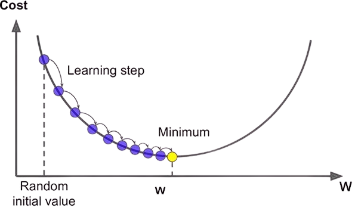

#### 4.4. Modèle de neurone

On peut modéliser un neurone artificiel comme un modèle de régression logistique. Un neurone prend en entrée des signaux $X = [x_1, x_2, ..., x_n]$ et renvoie une valeur de sortie $\hat{y}$.

La sortie du neurone est calculée comme suit (fonction d'activation sigmoïde) :

$$\hat{y} = \sigma(\omega^T X + b) = \sigma(\omega_1 x_1 + \omega_2 x_2 + ... + \omega_n x_n + b)$$

avec $\omega = [\omega_1, \omega_2, ..., \omega_n]$ les poids des connexions synaptiques et $b$ le biais du neurone.

#### 4.5. Fiabilité du modèle

On peut calculer la fiabilité de plusieurs manières :

- **Précision :** $\frac{VP}{VP + FP} = \frac{\text{Nombre de vrais positifs}}{\text{Nombre total de positifs annoncés}}$
- **Rappel :** $\frac{VP}{VP + FN} = \frac{\text{Nombre de vrais positifs}}{\text{Vrai nombre de positifs}}$
- **Fiabilité globale :** $\frac{VP + VN}{VP + VN + FP + FN} = \frac{\text{Nombre de bonnes prédictions}}{\text{Nombre total de prédictions}}$

## Partie II : Analyses factorielles

### 1. Analyse en composantes principales (ACP)

On considère $n$ variables $X_1, X_2, ..., X_n$, chacune de dimension $p$. L'objectif de l'ACP est de réduire la dimension de l'espace des variables en conservant le maximum d'information.

On cherche donc à trouver $q$ axes (composantes principales, $q<p$) qui permettent de représenter les données sans perdre trop d'information.

**Etapes de l'ACP :**

1. Centrer les données : $X_c = X - \bar{X}$,
2. Calculer la matrice de covariance : $V[X] = \frac{1}{n}X_c^TX_c$,
3. Diagonaliser la matrice de covariance :
   - Calculer les valeurs propres $\lambda_i$ : racines du polynôme caractéristique de $V[X]$, $det(V[X] - \lambda I) = 0$,
   - Déterminer les vecteurs propres $v_i$ de $V[X]$ : $V[X]v_i = \lambda_i v_i$,
   - Les vecteurs propres doivent être rangés par ordre décroissant de valeurs propres.
4. Déterminer la qualité des variables
   - Calculer la quantité totale d'information contenue dans les données : $\lambda = \sum_{i=1}^{p} \lambda_i$,
   - Calculer la proportion d'information contenue dans chaque axe : $q_i=\frac{\lambda_i}{\lambda}$,
   - Choisir le nombre d'axes à conserver en fonction de la quantité d'information souhaitée.
5. Calculer les composantes principales : $Y = X_cV$, avec $V = [v_1, v_2, ..., v_k]$ les vecteurs propres retenus.

Les composantes principales calculées sont les axes de l'ACP. Elles permettent de représenter les données dans un espace de dimension réduite.

Le coefficient de corrélation linéaire entre deux variables $X_i$ et $X_j$ est donné par :

$$r_{ij} = \frac{cov(X_i, X_j)}{\sigma_{ij}} = \frac{<X_i, X_j>}{\|X_i\| \|X_j\|} \cong cos(X_i, X_j)$$

On peut alors représenter ces corrélations dans un plan ayant pour axes deux composantes principales. Les variables qui sont proches dans le plan sont fortement corrélées.

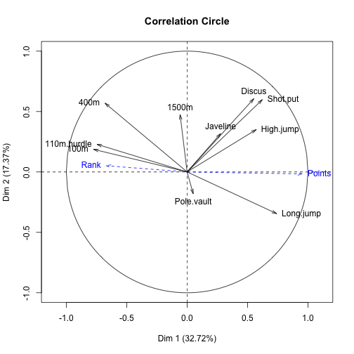

### 2. Analyse factorielle des correspondances (AFC)

**Tableau de contingence** : Tableau de croisement de deux variables *qualitatives*.

Exemple :

Soit X la filière d'études et Y le métier des parents :

| Y / X | Droit | Science | Médecine | IUT | Σ |
| --- | --- | --- | --- | --- | --- |
| Agriculteur | 80 | 99 | 65 | 58 | 302 |
| Patron | 168 | 137 | 208 | 62 | 575 |
| Cadre sup | 470 | 400 | 876 | 79 | 1825 |
| Employé | 145 | 133 | 135 | 54 | 467 |
| Ouvrier | 166 | 193 | 127 | 129 | 615 |
| Σ | 1029 | 962 | 1411 | 382 | 3784 |

Ici, par exemple, 127 étudiants en médecine ont un parent ouvrier.

$P(\text{Droit})=\frac{1029}{3784}=0.27$, $P(\text{Cadre sup})=\frac{1825}{3784}=0.48$, etc.  
$P_{\text{Cadre sup}}(\text{Droit})=P(\text{Droit}|\text{Cadre sup})=\frac{470}{1825}=0.25$

Si X et Y sont **indépendantes**, alors **$f_{X,Y}(x,y)=f_X(x)f_Y(y)$**.

Avec N=3784, on a :

$f_{i,j}=\frac{1}{N}n_{i,j}$ (avec $n_{i,j}$ le nombre d'individus de la catégorie i,j)

Pour connaitre la "distance" entre deux variables, on a $\frac{f_{X,Y}(x,y)}{f_X(x)f_Y(y)}-1=0$ (sous réserve d'indépendance).

On peut alors calculer la distance de $\chi^2$ :

$$\chi^2 = \sum_{i=1}^{n} \sum_{j=1}^{m} \frac{(f_{i,j}-f_{i}f_{j})^2}{f_{i}f_{j}}$$

*(voir exemple du cours (mais il est manuscrit parce que c'est chiant à faire les matrices lol))*

### 3. Analyse factorielle des données mixtes (AFDM)

En gros, c'est quand il y a à la fois des variables quantitatives et qualitatives dans le même dataset. On fait des ACP sur les variables quantitatives et des ACM sur les variables qualitatives.

Exemple :

| ID Personne | Note | Couleur chemise |
| --- | --- | --- |
| 1 | 17 | R |
| 2 | 19 | V |
| 3 | 10 | R |
| 4 | 16 | B |

Comment la couleur est qualitative, on compte une variable différente par possibilité.

Ainsi, on obtient :

| ID Personne | Note | Couleur chemise_R | Couleur chemise_V | Couleur chemise_B |
| --- | --- | --- | --- | --- |
| 1 | 17 | 1 | 0 | 0 |
| 2 | 19 | 0 | 1 | 0 |
| 3 | 10 | 1 | 0 | 0 |
| 4 | 16 | 0 | 0 | 1 |

Il y a donc désormais 4 variables quantitatives à étudier.